# Case Study: Facial Expression Recognition

[figure not shown]

# Introduction

The most expressive way humans display emotions is through facial expressions. Humans detect and interpret faces and facial expressions in a scene with little or no effort. An automated system could also be possible to accomplish this task by using a deep learning model that will be train based on Convolutional Neural Networks and Residual Blocks to detect facial expressions.

**Problem:**

- Classify the different facial expression

**Dataset:**

**Source:**

- This dataset was prepared by Pierre-Luc Carrier and Aaron Courville, as part of an ongoing research project. They have graciously provided the workshop organizers with a preliminary version of their dataset to use for this contest.

# Review

[figure not shown]

# Libraries And Data Importation

```python
# Import libraries
import cv2
import pandas as pd
import seaborn as sns
import matplotlib.pyplot as plt
import numpy as np
import os
import PIL
from tensorflow.keras import layers
import tensorflow as tf
import pickle
from tensorflow.python.keras import *
from tensorflow.keras.preprocessing.image import ImageDataGenerator
from tensorflow.keras import layers, optimizers
from tensorflow.keras.applications import DenseNet121
from tensorflow.keras.applications.resnet50 import ResNet50
from tensorflow.keras.layers import *
from tensorflow.keras.models import Model, load_model
from tensorflow.keras.initializers import glorot_uniform
from tensorflow.keras.utils import plot_model
from tensorflow.keras.callbacks import ReduceLROnPlateau, EarlyStopping, ModelCheckpoint, LearningRateScheduler
from IPython.display import display
from tensorflow.keras import backend as K
```

```python
# Import data
emotion_df = pd.read_csv('emotion.csv')
```

```python
# Check data
# Picture is represented by number based on pixel
emotion_df.head()
```

|  | emotion | pixels |
| --- | --- | --- |
| 0 | 0 | 70 80 82 72 58 58 60 63 54 58 60 48 89 115 121... |
| 1 | 0 | 151 150 147 155 148 133 111 140 170 174 182 15... |
| 2 | 2 | 24 32 36 30 32 23 19 20 30 41 21 22 32 34 21 1... |
| 3 | 2 | 20 17 19 21 25 38 42 42 46 54 56 62 63 66 82 1... |
| 4 | 3 | 77 78 79 79 78 75 60 55 47 48 58 73 77 79 57 5... |

```python
# Check data
emotion_df['emotion'][2]
```

```
2
```

```python
# Add space # String format
emotion_df['pixels'] = emotion_df[' pixels']
```

```python
# Check data # String format
emotion_df['pixels'][2]
```

```
'24 32 36 30 32 23 19 20 30 41 21 22 32 34 21 19 43 52 13 26 40 59 65 12 20 63 99 98 98 111 75 62 41 73 118 140 192 186 187 188 190 190 187 182 176 173 172 173 25 34 29 35 29 26 20 23 19 31 22 21 20 31 26 17 34 75 37 18 38 80 85 25 38 26 34 97 94 76 86 95 70 39 98 129 185 188 188 189 190 190 188 182…
```

```python
# Function to convert pixel values in string format to array format
def string2array(x):
  return np.array(x.split(' ')).reshape(48, 48, 1).astype('float32')
```

```python
# Apply the function
emotion_df['pixels'] = emotion_df['pixels'].apply(lambda x: string2array(x))
```

```python
# Check shape
emotion_df['pixels'][2].shape
```

```
(48, 48, 1)
```

```python
# Check data
emotion_df['pixels'][2];
```

```python
# Checking for the presence of null values in the data frame
emotion_df.isnull().sum()
```

```
emotion    0
 pixels    0
pixels     0
dtype: int64
```

```python
# Create label
label_to_text = {0:'anger', 1:'disgust', 2:'sad', 3:'happiness', 4: 'surprise'}
```

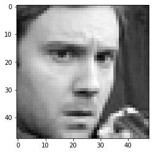

```python
# Check image
plt.imshow(emotion_df['pixels'][0].squeeze(), cmap = 'gray')
plt.show()
```

# Data Visualization

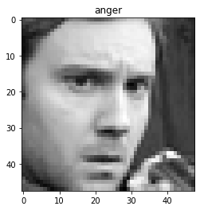

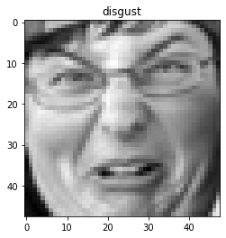

[figure not shown]

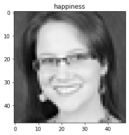

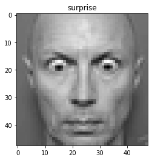

```python
# Create List
emotions = [0,1,2,3,4]

# Create function
for i in emotions:
  data = emotion_df[emotion_df['emotion'] == i][:1]
  img = data['pixels'].item()
  img = img.reshape(48,48)
  plt.figure()
  plt.title(label_to_text[i])
  plt.imshow(img, cmap= 'gray')
```

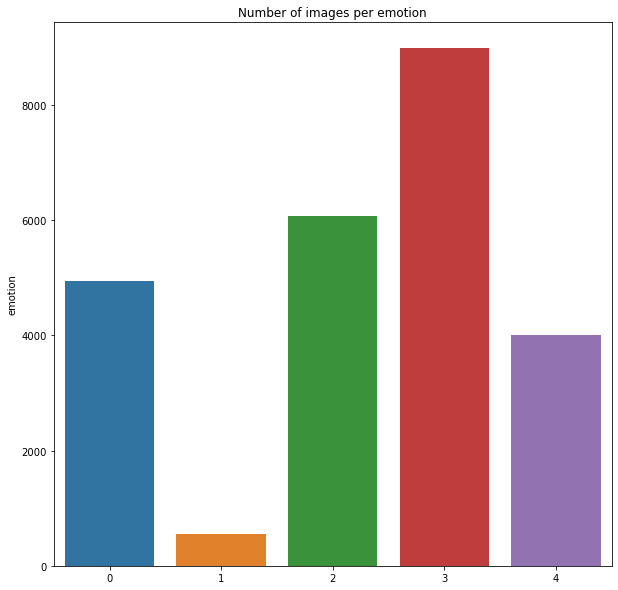

```python
# Create barplot
plt.figure(figsize = (10, 10))
sns.barplot(x = emotion_df.emotion.value_counts().index, y = emotion_df['emotion'].value_counts())
plt.title("Number of images per emotion")
plt.show()
```

# Data Preprocessing

```python
# Split the dataframe to features and labels
# From keras.utils import to_categorical
X = emotion_df['pixels']
X = np.stack(X, axis = 0)
X = X.reshape(24568, 48, 48, 1)

# y = to_categorical(emotion_df['emotion'])
y = pd.get_dummies(emotion_df['emotion'])

# Show data dimensions
print(X.shape, y.shape)
```

```
(24568, 48, 48, 1) (24568, 5)
```

```python
# Transform data into arrays
X = np.array(X)
y = np.array(y)
```

```python
# Import lirabries
from sklearn.model_selection import train_test_split

# spliting the dataframe in to train,test and validation data frames
X_train, X_Test, y_train, y_Test = train_test_split(X,y,test_size = 0.1, shuffle = True)
X_val, X_Test, y_val, y_Test = train_test_split(X_Test,y_Test, test_size = 0.5, shuffle = True)
```

```python
# Check train dataset
print(X_train.shape, y_train.shape)
```

```
(22111, 48, 48, 1) (22111, 5)
```

```python
# Check validation dataset
print(X_val.shape, y_val.shape)
```

```
(1228, 48, 48, 1) (1228, 5)
```

```python
# Check test dataset
print(X_Test.shape, y_Test.shape)
```

```
(1229, 48, 48, 1) (1229, 5)
```

```python
# Normalize images
X_train = X_train/255
X_val   = X_val /255
X_Test  = X_Test/255
```

```python
# Data augmentation
train_datagen = ImageDataGenerator(
rotation_range = 15,
    width_shift_range = 0.1,
    height_shift_range = 0.1,
    shear_range = 0.1,
    zoom_range = 0.1,
    fill_mode = "nearest"
)
```

# CNN And Residual Neural Network

```python
# Create funchtion
def res_block(X, filter, stage):

  # Convolutional_block
  X_copy = X

  f1 , f2, f3 = filter

  # Main Path
  X = Conv2D(f1, (1,1),strides = (1,1), name ='res_'+str(stage)+'_conv_a', kernel_initializer= glorot_uniform(seed = 0))(X)
  X = MaxPool2D((2,2))(X)
  X = BatchNormalization(axis =3, name = 'bn_'+str(stage)+'_conv_a')(X)
  X = Activation('relu')(X)

  X = Conv2D(f2, kernel_size = (3,3), strides =(1,1), padding = 'same', name ='res_'+str(stage)+'_conv_b', kernel_initializer= glorot_uniform(seed = 0))(X)
  X = BatchNormalization(axis =3, name = 'bn_'+str(stage)+'_conv_b')(X)
  X = Activation('relu')(X)

  X = Conv2D(f3, kernel_size = (1,1), strides =(1,1),name ='res_'+str(stage)+'_conv_c', kernel_initializer= glorot_uniform(seed = 0))(X)
  X = BatchNormalization(axis =3, name = 'bn_'+str(stage)+'_conv_c')(X)


  # Short path
  X_copy = Conv2D(f3, kernel_size = (1,1), strides =(1,1),name ='res_'+str(stage)+'_conv_copy', kernel_initializer= glorot_uniform(seed = 0))(X_copy)
  X_copy = MaxPool2D((2,2))(X_copy)
  X_copy = BatchNormalization(axis =3, name = 'bn_'+str(stage)+'_conv_copy')(X_copy)

  # ADD
  X = Add()([X,X_copy])
  X = Activation('relu')(X)

  # Identity Block 1
  X_copy = X


  # Main Path
  X = Conv2D(f1, (1,1),strides = (1,1), name ='res_'+str(stage)+'_identity_1_a', kernel_initializer= glorot_uniform(seed = 0))(X)
  X = BatchNormalization(axis =3, name = 'bn_'+str(stage)+'_identity_1_a')(X)
  X = Activation('relu')(X)

  X = Conv2D(f2, kernel_size = (3,3), strides =(1,1), padding = 'same', name ='res_'+str(stage)+'_identity_1_b', kernel_initializer= glorot_uniform(seed = 0))(X)
  X = BatchNormalization(axis =3, name = 'bn_'+str(stage)+'_identity_1_b')(X)
  X = Activation('relu')(X)

  X = Conv2D(f3, kernel_size = (1,1), strides =(1,1),name ='res_'+str(stage)+'_identity_1_c', kernel_initializer= glorot_uniform(seed = 0))(X)
  X = BatchNormalization(axis =3, name = 'bn_'+str(stage)+'_identity_1_c')(X)

  # ADD
  X = Add()([X,X_copy])
  X = Activation('relu')(X)

  # Identity Block 2
  X_copy = X


  # Main Path
  X = Conv2D(f1, (1,1),strides = (1,1), name ='res_'+str(stage)+'_identity_2_a', kernel_initializer= glorot_uniform(seed = 0))(X)
  X = BatchNormalization(axis =3, name = 'bn_'+str(stage)+'_identity_2_a')(X)
  X = Activation('relu')(X)

  X = Conv2D(f2, kernel_size = (3,3), strides =(1,1), padding = 'same', name ='res_'+str(stage)+'_identity_2_b', kernel_initializer= glorot_uniform(seed = 0))(X)
  X = BatchNormalization(axis =3, name = 'bn_'+str(stage)+'_identity_2_b')(X)
  X = Activation('relu')(X)

  X = Conv2D(f3, kernel_size = (1,1), strides =(1,1),name ='res_'+str(stage)+'_identity_2_c', kernel_initializer= glorot_uniform(seed = 0))(X)
  X = BatchNormalization(axis =3, name = 'bn_'+str(stage)+'_identity_2_c')(X)

  # ADD
  X = Add()([X,X_copy])
  X = Activation('relu')(X)

  return X
```

```python
# Input tensor shape
input_shape = (48, 48, 1)

# Input tensor shape
X_input = Input(input_shape)

# Zero-padding
X = ZeroPadding2D((3, 3))(X_input)

# 1 - stage
X = Conv2D(64, (7, 7), strides= (2, 2), name = 'conv1', kernel_initializer= glorot_uniform(seed = 0))(X)
X = BatchNormalization(axis =3, name = 'bn_conv1')(X)
X = Activation('relu')(X)
X = MaxPooling2D((3, 3), strides= (2, 2))(X)

# 2 - stage
X = res_block(X, filter= [64, 64, 256], stage= 2)

# 3 - stage
X = res_block(X, filter= [128, 128, 512], stage= 3)

# 4 - stage
# X = res_block(X, filter= [256, 256, 1024], stage= 4)

# Average Pooling
X = AveragePooling2D((2, 2), name = 'Averagea_Pooling')(X)

# Final layer
X = Flatten()(X)
X = Dense(5, activation = 'softmax', name = 'Dense_final', kernel_initializer= glorot_uniform(seed=0))(X)

# Model architecture
model_emotion = Model( inputs= X_input, outputs = X, name = 'Resnet18')

# Check model summary
model_emotion.summary()
```

```
Model: "Resnet18"
__________________________________________________________________________________________________
Layer (type)                    Output Shape         Param #     Connected to
==================================================================================================
input_1 (InputLayer)            [(None, 48, 48, 1)]  0
__________________________________________________________________________________________________
zero_padding2d (ZeroPadding2D)  (None, 54, 54, 1)    0           input_1[0][0]
__________________________________________________________________________________________________
conv1 (Conv2D)                  (None, 24, 24, 64)   3200        zero_padding2d[0][0]
__________________________________________________________________________________________________
bn_conv1 (BatchNormalization)   (None, 24, 24, 64)   256         conv1[0][0]
__________________________________________________________________________________________________
activation (Activation)         (None, 24, 24, 64)   0           bn_conv1[0][0]
__________________________________________________________________________________________________
max_pooling2d (MaxPooling2D)    (None, 11, 11, 64)   0           activation[0][0]
__________________________________________________________________________________________________
res_2_conv_a (Conv2D)           (None, 11, 11, 64)   4160        max_pooling2d[0][0]
__________________________________________________________________________________________________
max_pooling2d_1 (MaxPooling2D)  (None, 5, 5, 64)     0           res_2_conv_a[0][0]
__________________________________________________________________________________________________
bn_2_conv_a (BatchNormalization (None, 5, 5, 64)     256         max_pooling2d_1[0][0]
__________________________________________________________________________________________________
activation_1 (Activation)       (None, 5, 5, 64)     0           bn_2_conv_a[0][0]
__________________________________________________________________________________________________
res_2_conv_b (Conv2D)           (None, 5, 5, 64)     36928       activation_1[0][0]
__________________________________________________________________________________________________
bn_2_conv_b (BatchNormalization (None, 5, 5, 64)     256         res_2_conv_b[0][0]
__________________________________________________________________________________________________
activation_2 (Activation)       (None, 5, 5, 64)     0           bn_2_conv_b[0][0]
__________________________________________________________________________________________________
res_2_conv_copy (Conv2D)        (None, 11, 11, 256)  16640       max_pooling2d[0][0]
__________________________________________________________________________________________________
res_2_conv_c (Conv2D)           (None, 5, 5, 256)    16640       activation_2[0][0]
__________________________________________________________________________________________________
max_pooling2d_2 (MaxPooling2D)  (None, 5, 5, 256)    0           res_2_conv_copy[0][0]
__________________________________________________________________________________________________
bn_2_conv_c (BatchNormalization (None, 5, 5, 256)    1024        res_2_conv_c[0][0]
__________________________________________________________________________________________________
bn_2_conv_copy (BatchNormalizat (None, 5, 5, 256)    1024        max_pooling2d_2[0][0]
__________________________________________________________________________________________________
```

[output cut: 113 more lines]

```
add_5 (Add)                     (None, 2, 2, 512)    0           bn_3_identity_2_c[0][0]
                                                                 activation_15[0][0]
__________________________________________________________________________________________________
activation_18 (Activation)      (None, 2, 2, 512)    0           add_5[0][0]
__________________________________________________________________________________________________
Averagea_Pooling (AveragePoolin (None, 1, 1, 512)    0           activation_18[0][0]
__________________________________________________________________________________________________
flatten (Flatten)               (None, 512)          0           Averagea_Pooling[0][0]
__________________________________________________________________________________________________
Dense_final (Dense)             (None, 5)            2565        flatten[0][0]
==================================================================================================
Total params: 1,174,021
Trainable params: 1,165,445
Non-trainable params: 8,576
__________________________________________________________________________________________________
```

```python
# Compile the network
model_emotion.compile(optimizer = "Adam", loss = "categorical_crossentropy", metrics = ["accuracy"])
```

```python
# Using early stopping to exit training if validation loss is not decreasing even after certain epochs (patience)
earlystopping = EarlyStopping(monitor = 'val_loss', mode = 'min', verbose = 1, patience = 20)

# Save the best model with lower validation loss
checkpointer = ModelCheckpoint(filepath = "FacialExpression_weights.hdf5", verbose = 1, save_best_only=True)
```

```python
# Train the model
history = model_emotion.fit(train_datagen.flow(X_train, y_train, batch_size = 64),
    validation_data = (X_val, y_val), steps_per_epoch = len(X_train) // 64,
    epochs= 10, callbacks = [checkpointer, earlystopping])
```

```
Epoch 00001: val_loss improved from inf to 1.83491, saving model to FacialExpression_weights.hdf5
Epoch 00002: val_loss improved from 1.83491 to 1.35695, saving model to FacialExpression_weights.hdf5
Epoch 00003: val_loss improved from 1.35695 to 1.30362, saving model to FacialExpression_weights.hdf5
Epoch 00004: val_loss improved from 1.30362 to 0.95248, saving model to FacialExpression_weights.hdf5
Epoch 00005: val_loss did not improve from 0.95248
Epoch 00006: val_loss did not improve from 0.95248
Epoch 00007: val_loss did not improve from 0.95248
Epoch 00008: val_loss improved from 0.95248 to 0.94036, saving model to FacialExpression_weights.hdf5
Epoch 00009: val_loss improved from 0.94036 to 0.93946, saving model to FacialExpression_weights.hdf5
Epoch 00010: val_loss did not improve from 0.93946
```

```python
# Saving the model architecture to json file for future use
model_json = model_emotion.to_json()
with open("Emotion-model.json","w") as json_file:
  json_file.write(model_json)
```

# Model Evaluation

```python
# Import model architecture
with open('Emotion-model.json', 'r') as json_file:
    json_savedModel= json_file.read()

# load the model architecture
model_emotion = tf.keras.models.model_from_json(json_savedModel)
model_emotion.load_weights('FacialExpression_weights.hdf5')
model_emotion.compile(optimizer = "Adam", loss = "categorical_crossentropy", metrics = ["accuracy"])
```

```python
# Check test accuracy
score = model_emotion.evaluate(X_Test, y_Test)
print('Test Accuracy: {}'.format(score[1]))
```

```
Test Accuracy: 0.6484947204589844
```

```python
# Check dictionary
history.history.keys()
```

```
dict_keys(['loss', 'accuracy', 'val_loss', 'val_accuracy'])
```

```python
# Check evaluation metrics
accuracy = history.history['accuracy']
val_accuracy = history.history['val_accuracy']
loss = history.history['loss']
val_loss = history.history['val_loss']
```

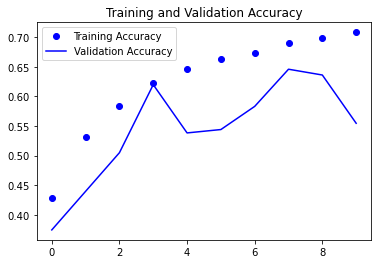

```python
# Number of iterations
epochs = range(len(accuracy))

# Create plot for accuracy
plt.plot(epochs, accuracy, 'bo', label='Training Accuracy')
plt.plot(epochs, val_accuracy, 'b', label='Validation Accuracy')
plt.title('Training and Validation Accuracy')
plt.legend()
plt.show()
```

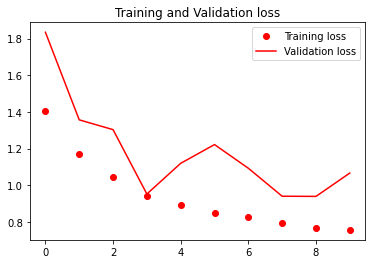

```python
# Create plot for validation loss
plt.plot(epochs, loss, 'ro', label='Training loss')
plt.plot(epochs, val_loss, 'r', label='Validation loss')
plt.title('Training and Validation loss')
plt.legend()
plt.show()
```

```python
# Predicted_classes = model.predict_classes(X_test)
predicted_classes = np.argmax(model_emotion.predict(X_Test), axis=-1)
y_true = np.argmax(y_Test, axis=-1)
```

```python
# Check data dimension
y_true.shape
```

```
(1229,)
```

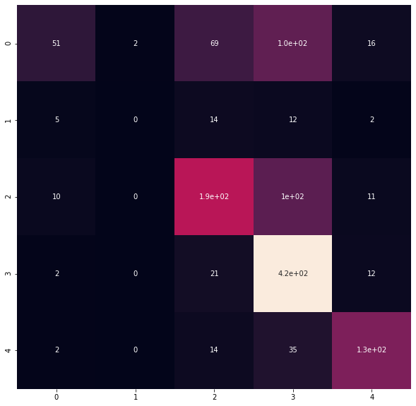

```python
# import library
from sklearn.metrics import confusion_matrix

# Confusion matrix
cm = confusion_matrix(y_true, predicted_classes)
plt.figure(figsize = (10, 10))
sns.heatmap(cm, annot = True, cbar = False)
plt.show()
```

[figure not shown]

```python
# Length
L = 5

# Width
W = 5

fig, axes = plt.subplots(L, W, figsize = (24, 24))
axes = axes.ravel()

for i in np.arange(0, L*W):
    axes[i].imshow(X_Test[i].reshape(48,48), cmap = 'gray')
    axes[i].set_title('Prediction = {}\n True = {}'.format(label_to_text[predicted_classes[i]], label_to_text[y_true[i]]))
    axes[i].axis('off')

plt.subplots_adjust(wspace = 1)
plt.show()
```

```python
# Import lirabry
from sklearn.metrics import classification_report

# Check classification report
print(classification_report(y_true, predicted_classes))
```

```
              precision    recall  f1-score   support

           0       0.73      0.21      0.33       243
           1       0.00      0.00      0.00        33
           2       0.62      0.61      0.62       312
           3       0.63      0.92      0.75       456
           4       0.77      0.72      0.74       185

    accuracy                           0.65      1229
   macro avg       0.55      0.49      0.49      1229
weighted avg       0.65      0.65      0.61      1229
```

# Conclusion

It can be observed that the photos showing disgust has the lowest accuracy score it is because the data was imbalance. The solution to that is to add more examples by generating more augmented images or adjusting the weights of disgust photos. the model was able to obtained 65% accuracy with only 10 iterations. There are several related problems: detection of an image segment as a face, extraction of the facial expression information, and classification of the expression.This could be further improve by tuning the model hyper parameters and increasing the training iterations.